# load_iris

### Step 4: Visualize the data - Using MatplotLib and Seaborn

```python
df['species'] = [target_names[i] for i in Y]  # Adds a column 'species' with the species name for each row.
```

```python
print(df.head())
```

```
   sepal length (cm)  sepal width (cm)  petal length (cm)  petal width (cm)  \
0                5.1               3.5                1.4               0.2
1                4.9               3.0                1.4               0.2
2                4.7               3.2                1.3               0.2
3                4.6               3.1                1.5               0.2
4                5.0               3.6                1.4               0.2

  species
0  setosa
1  setosa
2  setosa
3  setosa
4  setosa
```

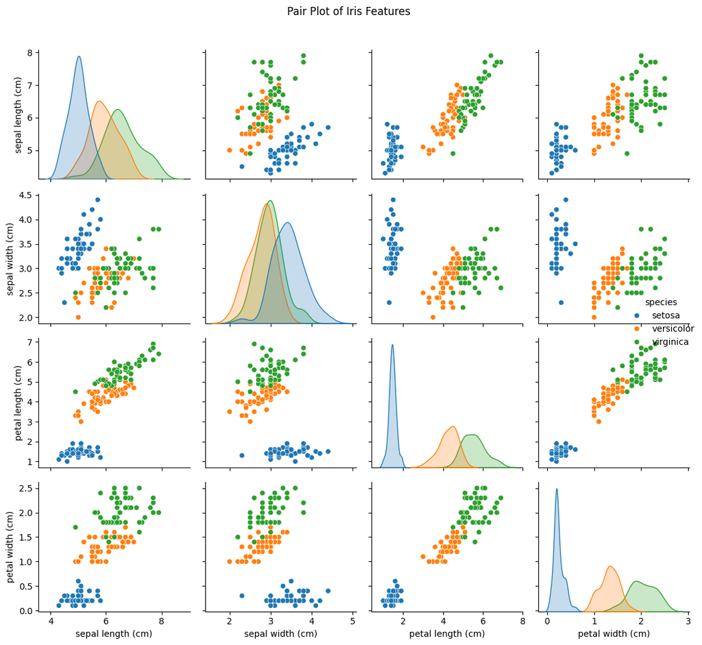

```python
plt.figure(figsize=(12, 8))
sns.pairplot(df, hue='species') #This plots pairwise relationships between all 4 features, color-coded by species.
plt.suptitle('Pair Plot of Iris Features', y=1.02)
plt.tight_layout()
plt.show()
```

### Step 5: Split the Data for Training & Testing - Using Skilearn

The given dataset needs to be split into two categoreis -

1. For **Training** - This dataset will be used for training the machine to identify the targets based on the features. Can be kept aorund 80-85 percent
2. For **Testing** - This dataset will be used for testing/validating the trained machine. Can be kept around 15-20 percent.

```python
X_train, X_test, Y_train, Y_test = train_test_split(X, Y, test_size=0.2, random_state=42)
#test_size=0.2 i.e. test data will be 20%
```

```python
print(f"Size of Dataset for Training: {X_train.shape[0]} samples")
```

```
Size of Dataset for Training: 120 samples
```

```python
print(f"Size of Dataset for Testing: {X_test.shape[0]} samples")
```

```
Size of Dataset for Testing: 30 samples
```

### Step 6: Train the Model

Using Logistic Regression, which is a simple but powerful classification algorithm.

```python
model = LogisticRegression(max_iter=1000)  # max_iter=1000 allows more iterations if convergence is slow.
model.fit(X_train, Y_train)
print("Model training completed!")
```

```
Model training completed!
```

### Step 7: Test the Model and make predictions

```python
Y_pred = model.predict(X_test)
accuracy = accuracy_score(Y_test, Y_pred)
print(f"\nModel Accuracy: {accuracy:.2f}")
```

```
Model Accuracy: 1.00
```

```python
## Step 8: Generate Confusion Matrix
```

A confusion matrix is a performance evaluation tool used in classification problems to visualize how well a machine learning model is performing, especially when dealing with multiple classes. **Confusion matrix shows where the model makes mistakes.** Shows not just how many predictions were correct, but what kind of errors were made.Helps in understanding if a particular class is being confused with another (e.g., Versicolor vs Virginica).

```python
# Generate confusion matrix
cm = confusion_matrix(Y_test, Y_pred)
```

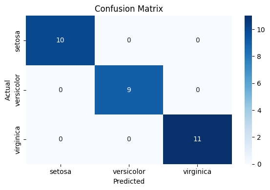

```python
# Plot confusion matrix as heatmap
plt.figure(figsize=(6, 4))
sns.heatmap(cm, annot=True, fmt='d', cmap='Blues', xticklabels=target_names, yticklabels=target_names)
plt.xlabel('Predicted')
plt.ylabel('Actual')
plt.title('Confusion Matrix')
plt.tight_layout()
plt.show()
```